# Automated testing in R using testthat

31 January 2019

## tldr;

- Everyone tests already
- Automate those tests
- Create the tests before you code

## tldr

Automated test-driven development makes your code:

- easier and faster to write
- less prone to bugs
- easier to amend
- easier to review

## What is a test

- A test is code that tests the behaviour of your code
- They are about testing WHAT your code does, not HOW

## What is a test

```r
expect_equal (
  object = 1 + 1, # This is a function call - `+`(1, 1)
  expected = 2
  )
```

## What is a test

```r
expect_equal (
  object = 1 + 1,
  expected = 2
  )
```

## What to test

[figure not shown]

## What to test

There is a fine balance between what (and how many) tests you should write.

A short simple piece of code should not have a lot of tests

… but if you don't have enough tests, you could miss problems

## What to test

[figure not shown]

## What to test

General output behaviour

- a number + a number outputs a number
- what happens if we pass a character?
- … a vector of numbers?
- … an empty vector?
- …NA?
- … a numeric vector with an NA in?

## What to test

Specific output behaviour:

- 1 + 1 = 2
- 1 + 0 = 1
- 1 + (-1) = 0
- c(1, 2, 3) + 1 = c(2, 3, 4)
- c(1, 2, 3) + c(1, 2, 3) = c(2, 4, 6)
- a + b > a for b > 0
- a + b < a for b < 0

## Some jargon

Unit testing is about writing tests for the smallest testable component of your code. If you are using R, this is about testing functions.

- A unit is the smallest testable component of code (in R, probably a function)
- Integration testing tests how units work together
- System testing tests the integration of all units

## Test-driven development

THIS IS THE MOST IMPORTANT BIT

## Test-driven development

[figure not shown]

## Benefits

- robust planning of code behaviour
- harder to fix a bug and inadvertantly create a new one without noticing
- faster checking of completed code
- reviewed code can be refactored without having to be re-reviewed
- users can be confident code is working correctly

## Drawbacks

## Drawbacks

- Writing too many unnecessary tests is a drain on your time
- Poorly thought-out tests can lead to overestimates of robustness

## Writing automated tests in R

- The *testthat* package
- Contains functions that help you write tests
- Contains functions that let you automate testing on scripts, directories and packages

I have an (ordered) shopping list and a budget

What do I buy?

## Continuous integration

There are many online tools that help track test coverage of your code.

My major project uses codecov.io

[figure not shown]

## Continuous integration

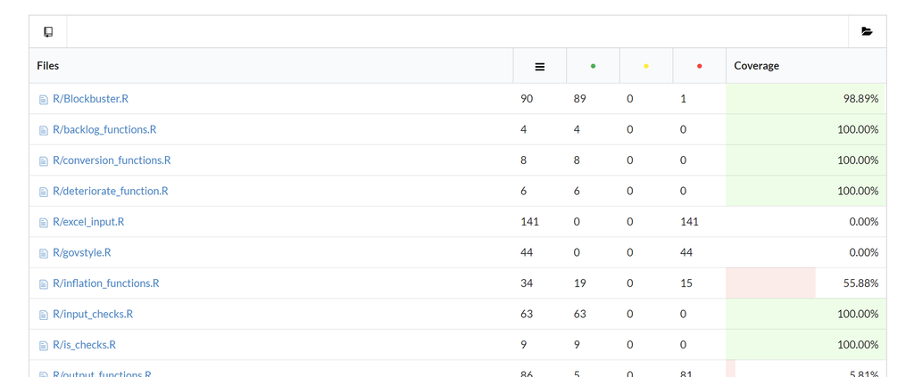

## REFS

https://github.com/r-lib/testthat

https://journal.r-project.org/archive/2011/RJ-2011-002/RJ-2011-002.pdf

http://r-pkgs.had.co.nz/tests.html

https://www.burns-stat.com/pages/Tutor/R_inferno.pdf